# Analisis Bakul Pembeilan [Market Basket Analysis]

Nurul Irdina Zahirah Binti Abd Rahim

2023-10-13

## 1. Pemuatan Data

#### 1.1 Memuat naik data yang diperoleh daripada laman web Kaggle (https://www.kaggle.com/datasets/hunter0007/ecommerce-dataset-for-predictive-marketing-2023/data) ke dalam R dan namakan data tersebut sebagai “hunter”.

```r
# Tukarkan lokasi fail mengikut nama yang ditetapkan di dalam komputer anda
load("/Users/zahirahrahim/Documents/FYP/FYP_code/Data/FYP_Zahirah.RData")

# Buat salinan data tersebut ke dalam pemboleh ubah "hunter"
hunter<- dat

# Jika data anda dalam bentuk fail csv.
# hunter<- read.csv(file.choose(), header = T)

# Untuk memaparkan 6  baris data pertama
head(hunter)
```

```
##   order_id user_id order_number order_dow order_hour_of_day
## 1  2425083   49125            1         2                18
## 2  2425083   49125            1         2                18
## 3  2425083   49125            1         2                18
## 4  2425083   49125            1         2                18
## 5  2425083   49125            1         2                18
## 6  2425083   49125            1         2                18
##   days_since_prior_order product_id add_to_cart_order reordered department_id
## 1                     NA         17                 1         0            13
## 2                     NA         91                 2         0            16
## 3                     NA         36                 3         0            16
## 4                     NA         83                 4         0             4
## 5                     NA         83                 5         0             4
## 6                     NA         91                 6         0            16
##   department       product_name
## 1     pantry baking ingredients
## 2 dairy eggs    soy lactosefree
## 3 dairy eggs             butter
## 4    produce   fresh vegetables
## 5    produce   fresh vegetables
## 6 dairy eggs    soy lactosefree
```

```r
# Untuk memaparkan saiz setiap pemboleh ubah
sapply(hunter, function(x) length(unique(x)))
```

```
##               order_id                user_id           order_number
##                 200000                 105273                    100
##              order_dow      order_hour_of_day days_since_prior_order
##                      7                     24                     32
##             product_id      add_to_cart_order              reordered
##                    134                    137                      2
##          department_id             department           product_name
##                     21                     21                    134
```

## 2. Pemuatan “library” yang akan digunakan

```r
library(arules)
```

```r
library(arulesViz)
library(tidyverse)
library(dplyr)
library(ggplot2)
```

## 3. Pembersihan data

#### 3.1 Pembuangan pemboleh ubah yang tidak digunakan dalam analisis

```r
hunter_c <- hunter[, -c(2,3,6,7,8,10)]
```

#### 3.2 Pembuangan produk yang tidak dapat dikenalpasti dan hilang dalam setiap data transaksi

> Di dalam set data transaksi Hunter’s e-grocery, terdapat beberapa produk yang tidak dapat dikenalpasti dan telah dinamakan sebagai “missing” dan “other”. Oleh kerana, kita tidak berminat untuk mencari hubungan diantara produk tersebut dengan produk lain kita perlulah membuangnya daripada set data.

```r
# Untuk membuang produk yang hilang
hunter_c <- hunter_c[!(hunter_c$product_name=='missing'),]

# Untuk membuang produk yang tidak dapat dikenalpasti
hunter_c <- hunter_c[!(hunter_c$product_name=='other'),]

# Untuk membuang baris data yang tidak lengkap
hunter_c[is.na(hunter_c)]<- 0

# Untuk memparkan 6 baris pertama data
head(hunter_c)
```

```
## # A tibble: 6 × 6
##   order_id order_dow order_hour_of_day reordered department product_name
##      <dbl>     <dbl>             <dbl>     <dbl> <chr>      <chr>
## 1  2425083         2                18         0 pantry     baking ingredients
## 2  2425083         2                18         0 dairy eggs soy lactosefree
## 3  2425083         2                18         0 dairy eggs butter
## 4  2425083         2                18         0 produce    fresh vegetables
## 5  2425083         2                18         0 produce    fresh vegetables
## 6  2425083         2                18         0 dairy eggs soy lactosefree
```

```r
# Untuk memaparkan saiz setiap pemboleh ubah selepas proses pembersihan data
sapply(hunter_c, function(x) length(unique(x)))
```

```
##          order_id         order_dow order_hour_of_day         reordered
##            199954                 7                24                 2
##        department      product_name
##                19               132
```

## 4. Penyediaan Data

#### 4.1 Penyediaan data bagi Analisis Penerokaan Data

> Bagi analisis penerokaan data yang akan dilaksanakan keatas pembolehubah “order_id”, “order_dow”, dan “order_hour_of_day”, setiap baris data perlu dikelaskan mengikut ID pesanan (order_id). Hal ini adalah supaya bilangan pesanan bagi setiap hari dan masa pembelian dapat dihitung dengan tepat.

```r
# Untuk mengelaskan data mengikut ID pesanan (order_id)
hunter_EDA<- hunter_c %>%
  group_by(order_id, order_dow, order_hour_of_day) %>%
  summarise(item = paste(product_name, collapse = ","))
# Untuk memaparkan 6 baris pertama data
head(hunter_EDA)
```

```
## # A tibble: 6 × 4
## # Groups:   order_id, order_dow [6]
##   order_id order_dow order_hour_of_day item
##      <dbl>     <dbl>             <dbl> <chr>
## 1       10         6                 8 fresh fruits,fresh vegetables,fresh herb…
## 2       11         1                19 frozen meals,fresh dips tapenades,canned…
## 3       28         3                13 butter,other creams cheeses,poultry coun…
## 4       38         6                16 nuts seeds dried fruit,packaged vegetabl…
## 5       56         0                12 canned jarred vegetables,packaged cheese…
## 6       62         0                11 seafood counter,soy lactosefree,packaged…
```

#### 4.2 Penyediaan data bagi analisis bakul pembelian

> Untuk menggunakan command “apriori()” dan “eclat()” bagi melaksanakan analisis bakul pembelian, data set “hunter” perlu ditukarkan kepada bentuk transaksi menggunakan perintah as() yang disediakan di dalam pakej arules.

```r
# Pecahkan data mengikut order ID dan nama produk
hunter_gr <- split(hunter_c$product_name, hunter_c$order_id)
head(hunter_gr)
```

```
## $`10`
##  [1] "fresh fruits"       "fresh vegetables"   "fresh herbs"
##  [4] "fresh fruits"       "fresh vegetables"   "fresh herbs"
##  [7] "fresh fruits"       "baby food formula"  "baby food formula"
## [10] "canned meals beans" "fresh vegetables"   "cream"
## [13] "meat counter"       "fresh vegetables"   "fresh vegetables"
##
## $`11`
## [1] "frozen meals"         "fresh dips tapenades" "canned meals beans"
## [4] "chips pretzels"       "oils vinegars"
##
## $`28`
##  [1] "butter"               "other creams cheeses" "poultry counter"
##  [4] "fresh fruits"         "milk"                 "fresh fruits"
##  [7] "spreads"              "fresh vegetables"     "packaged cheese"
```

[output cut: 23 more lines]

```r
# Tukarkan data kepada bentuk transaksi menggunakan pakej arules
hunter_trans <- as(hunter_gr, "transactions")
inspect(head(hunter_trans, 6))
```

```
##     items                         transactionID
## [1] {baby food formula,
##      canned meals beans,
##      cream,
##      fresh fruits,
##      fresh herbs,
##      fresh vegetables,
##      meat counter}                           10
## [2] {canned meals beans,
##      chips pretzels,
##      fresh dips tapenades,
##      frozen meals,
##      oils vinegars}                          11
## [3] {butter,
##      cream,
##      fresh fruits,
##      fresh vegetables,
##      milk,
##      other creams cheeses,
##      packaged cheese,
##      poultry counter,
##      spreads,
##      yogurt}                                 28
## [4] {fresh herbs,
##      fresh vegetables,
##      frozen produce,
##      nuts seeds dried fruit,
##      oils vinegars,
##      packaged vegetables fruits}             38
## [5] {canned jarred vegetables,
##      cream,
##      doughs gelatins bake mixes,
##      eggs,
##      fresh fruits,
##      fresh vegetables,
##      frozen produce,
##      packaged cheese,
##      packaged vegetables fruits,
##      refrigerated}                           56
## [6] {canned meals beans,
##      fresh fruits,
##      fresh vegetables,
##      packaged vegetables fruits,
##      seafood counter,
##      soy lactosefree}                        62
```

## 5. Analisis Penerokaan data

> Analisis ini dilaksanakan untuk memahami corak dan isi kandungan data dengan lebih mendalam.

#### 5.1 Bilangan transaksi pembelian pelanggan mengikut hari

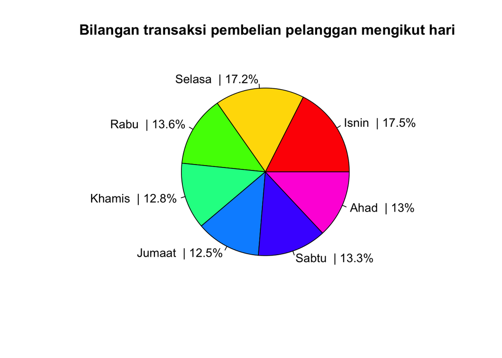

```r
# Untuk memaparkan bilangan transaksi pembelian pelanggan mengikut hari
hunter_day<- table(hunter_EDA$order_dow)

# Pemvisualan bilangan transaksi pembelian pelanggan mengikut hari [Carta pie]
days <- paste(c("Isnin", "Selasa", "Rabu","Khamis", "Jumaat", "Sabtu", "Ahad"), "  | ", (round((hunter_day/199954)*100,1)), "%", sep="")
pie(hunter_day, labels = days, main =" Bilangan transaksi pembelian pelanggan mengikut hari", col = rainbow(length(hunter_day)))
```

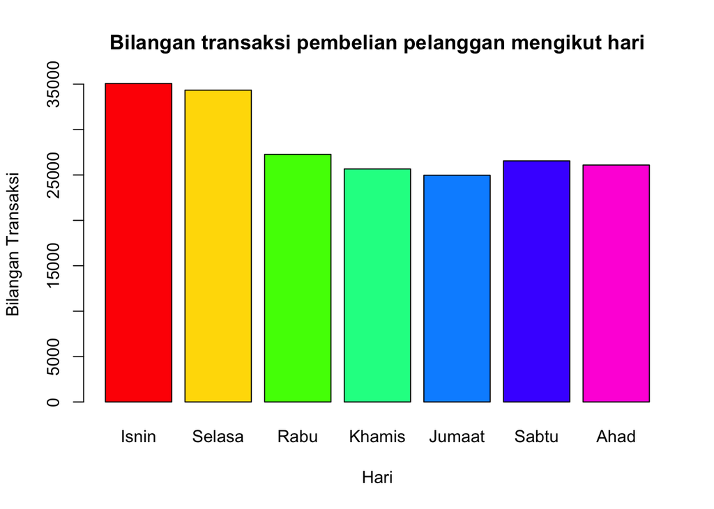

```r
# Pemvisualan bilangan transaksi pembelian pelanggan mengikut hari [Carta bar]
barplot(hunter_day,
main = "Bilangan transaksi pembelian pelanggan mengikut hari",
xlab = "Hari",
ylab = "Bilangan Transaksi",
names.arg = c("Isnin", "Selasa", "Rabu","Khamis", "Jumaat", "Sabtu", "Ahad"),
col = rainbow(length(hunter_day)),
horiz = FALSE)
```

#### 5.2 Bilangan transaksi pelanggan mengikut masa

```r
#
hunter_EDAt<- hunter_EDA[,c(1,3)]

# Kelaskan masa kepada Pagi, Tengahhari, Petang dan Malam
hunter_EDAt$Masa <- cut(hunter_EDAt$order_hour_of_day, breaks = c(-Inf,4,11,14,19,Inf),
                  labels = c("Malam","Pagi","Tengahhari","Petang","Malam"))

# Untuk memaparkan 6 data teratas
head(hunter_EDAt)
```

```
## # A tibble: 6 × 3
## # Groups:   order_id [6]
##   order_id order_hour_of_day Masa
##      <dbl>             <dbl> <fct>
## 1       10                 8 Pagi
## 2       11                19 Petang
## 3       28                13 Tengahhari
## 4       38                16 Petang
## 5       56                12 Tengahhari
## 6       62                11 Pagi
```

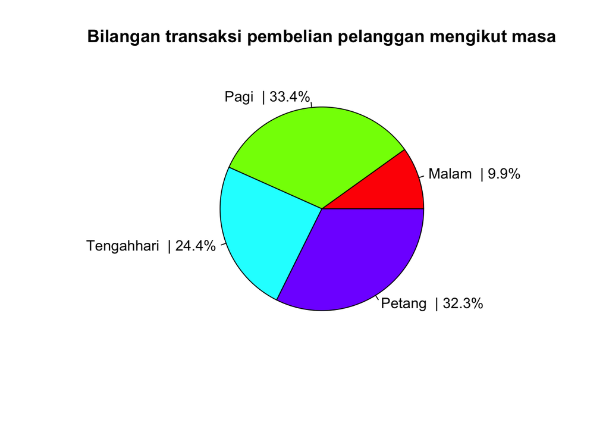

```r
# Untuk memaparkan bilangan transaksi pembelian pelanggan mengikut masa
hunter_time<-table(hunter_EDAt$Masa)

# Pemvisualan bilangan transaksi pembelian pelanggan mengikut masa [Carta pie]
time <- paste(c("Malam", "Pagi", "Tengahhari","Petang"), "  | ", (round((hunter_time/199954)*100,1)), "%", sep="")
pie(hunter_time, labels=time, main ="Bilangan transaksi pembelian pelanggan mengikut masa", col = rainbow(length(hunter_time)))
```

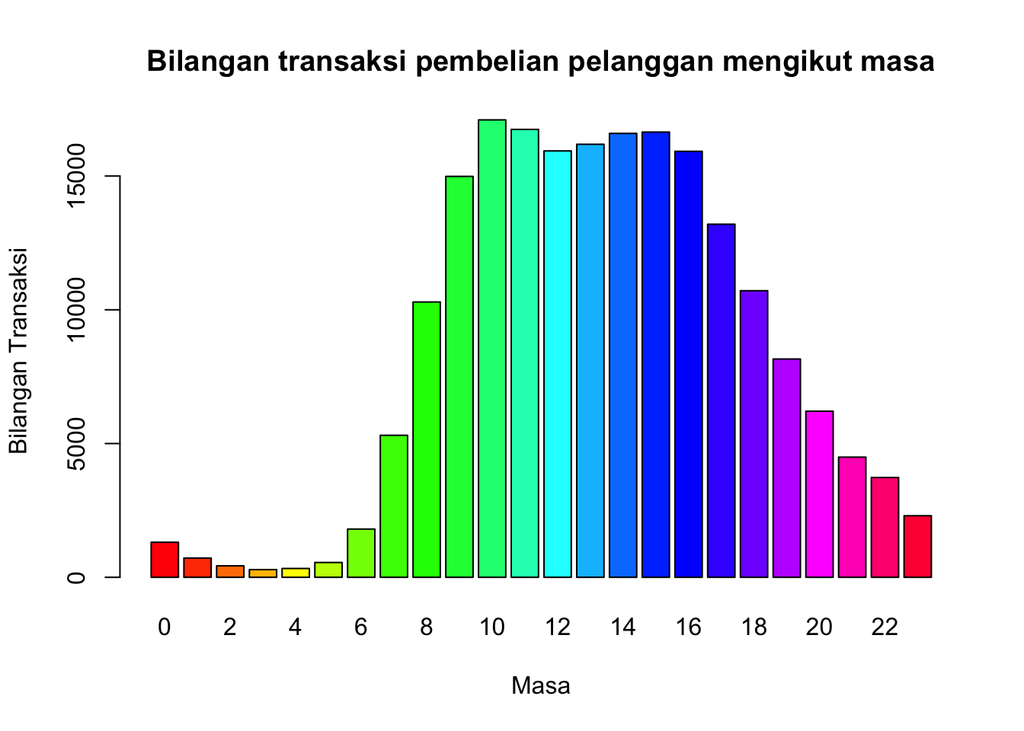

```r
# Pemvisualan bilangan transaksi pembelian pelanggan mengikut masa [Carta bar]
barplot(table(hunter_EDAt$order_hour_of_day),
main = "Bilangan transaksi pembelian pelanggan mengikut masa",
xlab = "Masa",
ylab = "Bilangan Transaksi",
names.arg = names(hunter_EDAt$order_hour_of_day),
col = rainbow(length(table(hunter_EDAt$order_hour_of_day))),
horiz = FALSE)
```

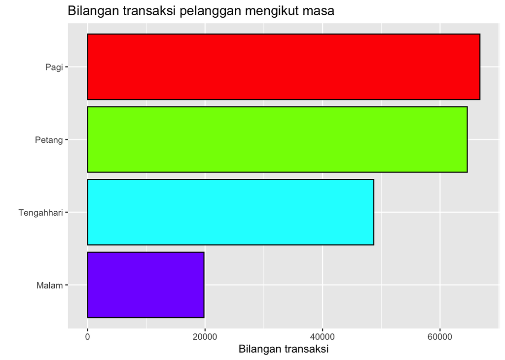

```r
# Pemvisualan bilangan transaksi pembelian pelanggan mengikut masa [0000-2300] [Carta bar]
hunter_EDAt %>%
  # Kelaskan data mengikut masa
  group_by(Masa) %>%
  # Hitung bilangan pembelian bagi setiap kumpulan masa
  summarize(count = n(), .groups = "drop") %>%
  # Susun data dalam turutan menurun
  arrange(desc(count)) %>%
  # Bina suatu carta bar
  ggplot(aes(
    # Susun semula masa mengikut bilangannya
    x = reorder(Masa, count),
    y = count
  )) +
  # Warnakan setiap bar dengan warna yang berlainan
  geom_bar(stat = "identity", fill = rainbow(length(hunter_time)), color ="black") +
  # Tambahkan tajuk pada carta
  labs(title = "Bilangan transaksi pelanggan mengikut masa", x = "", y = "Bilangan transaksi") +
  # Paparkan carta bar dalam bentuk melintang
  coord_flip()
```

```r
# Untuk memaparkan bilangan pembelian produk mengikut kategori dan nama produk
hunter_depit<- hunter_c %>%
  group_by(department,product_name) %>%
  # Calculate the count of each group and drop the grouping
  summarize(count = n(), .groups = "drop")
hunter_depit
```

```
## # A tibble: 132 × 3
##    department product_name               count
##    <chr>      <chr>                      <int>
##  1 alcohol    beers coolers               3002
##  2 alcohol    red wines                   2135
##  3 alcohol    specialty wines champagnes   614
##  4 alcohol    spirits                     1795
##  5 alcohol    white wines                 1893
##  6 babies     baby accessories             504
##  7 babies     baby bath body care          515
##  8 babies     baby food formula          23355
##  9 babies     diapers wipes               1566
## 10 bakery     bakery desserts             2214
## # ℹ 122 more rows
```

```r
# Untuk memaparkan bilangan pembelian produk mengikut kategori produk
hunter_dep <- table(hunter_c$department)
hunter_dep
```

```
##
##         alcohol          babies          bakery       beverages       breakfast
##            9439           25940           72983          168126           44605
##            bulk    canned goods      dairy eggs            deli dry goods pasta
##            2133           66053          336915           65176           54054
##          frozen       household   international    meat seafood          pantry
##          139536           46446           16738           44271          116262
##   personal care            pets         produce          snacks
##           28134            6013          588996          180692
```

#### 5.3 Bilangan pembelian mengikut kategori produk

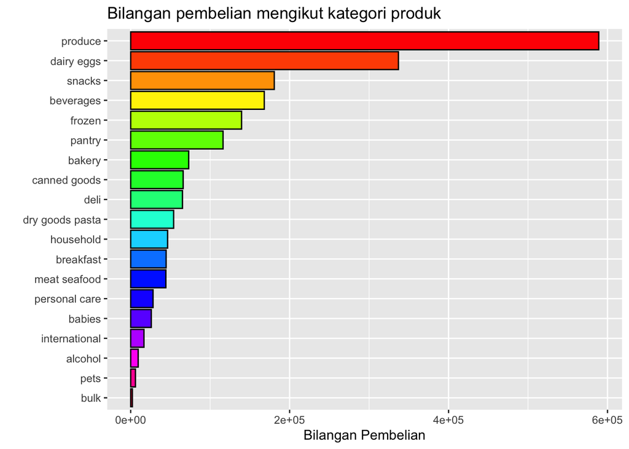

```r
hunter_c %>%
  # Kelaskan data mengikut kategori produk
  group_by(department) %>%
  # Hitung bilangan pembelian bagi setiap kumpulan kategori produk
  summarize(count = n(), .groups = "drop") %>%
  # Susun data dalam turutan menurun
  arrange(desc(count)) %>%
  # Bina suatu carta bar
  ggplot(aes(
    # Susun semula kategori produk mengikut bilangannya
    x = reorder(department, count),
    y = count
  )) +
  # Warnakan setiap bar dengan warna yang berlainan
  geom_bar(stat = "identity", fill = rainbow(length(hunter_dep)), color ="black") +
  # Tambahkan tajuk pada carta
  labs(title = "Bilangan pembelian mengikut kategori produk", x = "", y = "Bilangan Pembelian") +
  # Paparkan carta bar dalam bentuk melintang
  coord_flip()
```

#### 5.4 10 kategori produk yang kerap dibeli oleh pelanggan

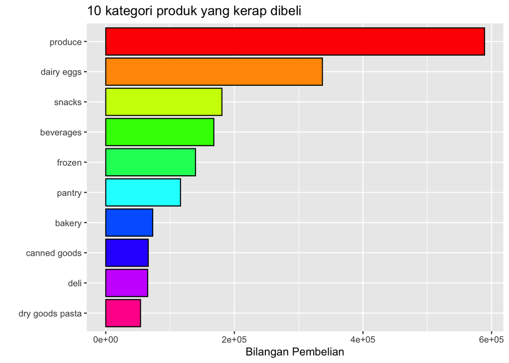

```r
hunter_dep2 <- hunter_c %>%
  # Kelaskan data mengikut kategori produk
  group_by(department) %>%
  # Hitung bilangan pembelian bagi setiap kategori produk
  summarize(count = n(), .groups = "drop") %>%
  # Susun data dalam turutan menurun
  arrange(desc(count)) %>%
  # Pilih hanya 10 kategori produk dengan bilangan terbanyak
  slice_max(order_by = count, n = 10)

hunter_dep2 %>%
  # Bina carta bar
  ggplot(aes(
    # Susun semula kategori produk mengikut bilangannya
    x = reorder(department, count),
    y = count
  )) +
  # Warnakan setiap bar dengan warna yang berlainan
  geom_bar(stat = "identity", fill = rainbow(length(hunter_dep2$department)), color ="black") +
  # Tambahkan tajuk pada carta
  labs(title = "10 kategori produk yang kerap dibeli", x = "", y = "Bilangan Pembelian") +
  # Paparkan carta bar dalam bentuk melintang
  coord_flip()
```

#### 5.5 10 produk yang kerap diulang pembelian oleh pelanggan

```r
hunter_reordered <-hunter_c %>%
  # Saringkan produk yang pernah dulang pembelian oleh pelanggan
  filter(reordered == 1) %>%
  # Kelaskan data mengikut produk
  group_by(product_name) %>%
  # Hitung bilangan pembelian bagi setiap produk
  summarize(count = n(), .groups = "drop") %>%
  # Susun data dalam turutan menurun
  arrange(desc(count)) %>%
  # Pilih hanya 10 produk dengan bilangan terbanyak
  slice_max(order_by = count, n = 10)
hunter_reordered
```

```
## # A tibble: 10 × 2
##    product_name                   count
##    <chr>                          <int>
##  1 fresh fruits                  162355
##  2 fresh vegetables              126171
##  3 packaged vegetables fruits     69872
##  4 yogurt                         62464
##  5 milk                           43162
##  6 water seltzer sparkling water  38467
##  7 packaged cheese                35864
##  8 soy lactosefree                27251
##  9 chips pretzels                 26615
## 10 bread                          24540
```

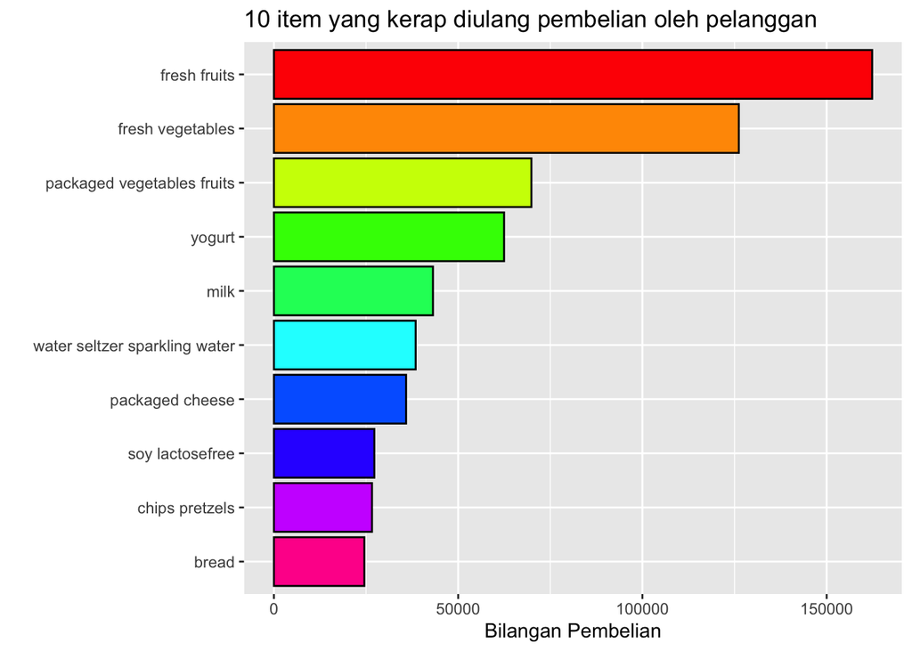

```r
  # Bina carta bar
hunter_reordered %>% ggplot(aes(
   # Susun semula produk mengikut bilangannya
    x = reorder(product_name, count),
    y = count
  )) +
  # Warnakan setiap bar dengan warna yang berlainan
  geom_bar(stat = "identity", fill = rainbow(length(hunter_reordered$product_name)), color ="black") +
  # Tambahkan tajuk pada carta
  labs(title = "10 item yang kerap diulang pembelian oleh pelanggan", x = "", y = "Bilangan Pembelian") +
  # Paparkan carta bar dalam bentuk melintang
  coord_flip()
```

#### 5.6 10 produk yang kerap dibeli oleh pelanggan

```r
hunter_item<-hunter_c %>%
  # Kelaskan data mengikut produk
  group_by(product_name) %>%
  # Hitung bilangan pembelian bagi setiap produk
  summarize(count = n(), .groups = "drop") %>%
  # Susun data dalam turutan menurun
  arrange(desc(count)) %>%
  # Pilih hanya 10 produk dengan bilangan terbanyak
  slice_max(order_by = count, n = 10)
hunter_item
```

```
## # A tibble: 10 × 2
##    product_name                   count
##    <chr>                          <int>
##  1 fresh fruits                  226039
##  2 fresh vegetables              212611
##  3 packaged vegetables fruits    109596
##  4 yogurt                         90751
##  5 packaged cheese                61502
##  6 milk                           55150
##  7 water seltzer sparkling water  52564
##  8 chips pretzels                 45306
##  9 soy lactosefree                39389
## 10 bread                          36381
```

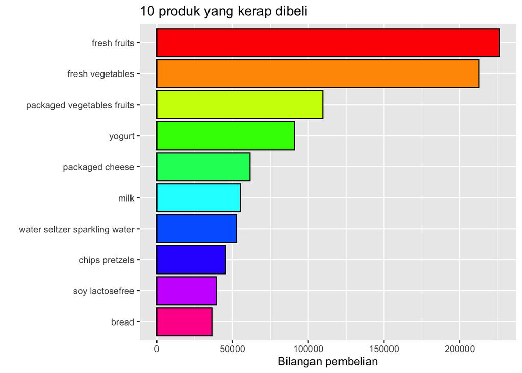

```r
  # Bina carta bar
hunter_item %>% ggplot(aes(
    # Susun semula produk mengikut bilangannya
    x = reorder(product_name, count),
    y = count
  )) +
  # Warnakan setiap bar dengan warna yang berlainan
  geom_bar(stat = "identity", fill = rainbow(length(hunter_item$product_name)), color ="black") +
  # Tambahkan tajuk pada carta
  labs(title = "10 produk yang kerap dibeli", x = "", y = "Bilangan pembelian") +
  # Paparkan carta bar dalam bentuk melintang
  coord_flip()
```

## Analisis Bakul Pembelian

> Oleh kerana set data yang digunakan adalah besar, terdapat kemungkinan untuk menghasilkan banyak aturan sekutuan yang tidak penting. Untuk mengurangkan risiko ini, nilai ambang minimum sokongan dan keyakinan boleh ditetapkan sebelum melaksanakan analisis untuk menghasilkan aturan yang berguna dan menarik sahaja. Oleh itu, nilai ambang minimum sokongan yang digunakan ialah 0.1 manakala, nilai ambang keyakinan yang digunakan ialah 0.7.

#### Algoritma Apriori

```r
## minimum support = 0.05
start_A <- Sys.time() #Untuk mengukur masa pelaksanaan algoritma Apriori

hunter_apriori<- apriori(hunter_trans, parameter = list(supp = 0.05, conf = 0.7, minlen = 2))
```

```
## Apriori
##
## Parameter specification:
##  confidence minval smax arem  aval originalSupport maxtime support minlen
##         0.7    0.1    1 none FALSE            TRUE       5    0.05      2
##  maxlen target  ext
##      10  rules TRUE
##
## Algorithmic control:
##  filter tree heap memopt load sort verbose
##     0.1 TRUE TRUE  FALSE TRUE    2    TRUE
##
## Absolute minimum support count: 9997
##
## set item appearances ...[0 item(s)] done [0.00s].
## set transactions ...[132 item(s), 199954 transaction(s)] done [0.11s].
## sorting and recoding items ... [49 item(s)] done [0.02s].
## creating transaction tree ... done [0.11s].
## checking subsets of size 1 2 3 4 done [0.06s].
## writing ... [43 rule(s)] done [0.00s].
## creating S4 object  ... done [0.04s].
```

```r
hunter_ap<- sort(hunter_apriori, by="confidence", decreasing = T)

end_A <- Sys.time() #
time_A<- as.numeric(end_A - start_A) #

## minimum support = 0.1
start_A2 <- Sys.time() #Untuk mengukur masa pelaksanaan algoritma Apriori

hunter_apriori2<- apriori(hunter_trans, parameter = list(supp = 0.1, conf = 0.7, minlen = 2))
```

```
## Apriori
##
## Parameter specification:
##  confidence minval smax arem  aval originalSupport maxtime support minlen
##         0.7    0.1    1 none FALSE            TRUE       5     0.1      2
##  maxlen target  ext
##      10  rules TRUE
##
## Algorithmic control:
##  filter tree heap memopt load sort verbose
##     0.1 TRUE TRUE  FALSE TRUE    2    TRUE
##
## Absolute minimum support count: 19995
##
## set item appearances ...[0 item(s)] done [0.00s].
## set transactions ...[132 item(s), 199954 transaction(s)] done [0.11s].
## sorting and recoding items ... [16 item(s)] done [0.01s].
## creating transaction tree ... done [0.09s].
## checking subsets of size 1 2 3 done [0.00s].
## writing ... [7 rule(s)] done [0.00s].
## creating S4 object  ... done [0.03s].
```

```r
hunter_ap2<- sort(hunter_apriori2, by="confidence", decreasing = T)

end_A2 <- Sys.time() #
time_A2 <- as.numeric(end_A2 - start_A2) #

arules::inspect(hunter_apriori2)
```

```
##     lhs                              rhs              support confidence  coverage     lift count
## [1] {yogurt}                      => {fresh fruits} 0.1882683  0.7138523 0.2637357 1.283623 37645
## [2] {packaged vegetables fruits}  => {fresh fruits} 0.2699321  0.7385302 0.3654991 1.327998 53974
## [3] {fresh vegetables}            => {fresh fruits} 0.3176331  0.7146458 0.4444622 1.285050 63512
## [4] {fresh vegetables,
##      packaged cheese}             => {fresh fruits} 0.1045941  0.7697460 0.1358813 1.384129 20914
## [5] {packaged vegetables fruits,
##      yogurt}                      => {fresh fruits} 0.1058143  0.8270659 0.1279394 1.487200 21158
## [6] {fresh vegetables,
##      yogurt}                      => {fresh fruits} 0.1184472  0.8186092 0.1446933 1.471993 23684
## [7] {fresh vegetables,
##      packaged vegetables fruits}  => {fresh fruits} 0.1866229  0.7954638 0.2346090 1.430374 37316
```

```r
arules::inspect(hunter_ap2)
```

```
##     lhs                              rhs              support confidence  coverage     lift count
## [1] {packaged vegetables fruits,
##      yogurt}                      => {fresh fruits} 0.1058143  0.8270659 0.1279394 1.487200 21158
## [2] {fresh vegetables,
##      yogurt}                      => {fresh fruits} 0.1184472  0.8186092 0.1446933 1.471993 23684
## [3] {fresh vegetables,
##      packaged vegetables fruits}  => {fresh fruits} 0.1866229  0.7954638 0.2346090 1.430374 37316
## [4] {fresh vegetables,
##      packaged cheese}             => {fresh fruits} 0.1045941  0.7697460 0.1358813 1.384129 20914
## [5] {packaged vegetables fruits}  => {fresh fruits} 0.2699321  0.7385302 0.3654991 1.327998 53974
## [6] {fresh vegetables}            => {fresh fruits} 0.3176331  0.7146458 0.4444622 1.285050 63512
## [7] {yogurt}                      => {fresh fruits} 0.1882683  0.7138523 0.2637357 1.283623 37645
```

```r
## minimum support = 0.15
start_A3 <- Sys.time() #Untuk mengukur masa pelaksanaan algoritma Apriori

hunter_apriori3<- apriori(hunter_trans, parameter = list(supp = 0.15, conf = 0.7, minlen = 2))
```

```
## Apriori
##
## Parameter specification:
##  confidence minval smax arem  aval originalSupport maxtime support minlen
##         0.7    0.1    1 none FALSE            TRUE       5    0.15      2
##  maxlen target  ext
##      10  rules TRUE
##
## Algorithmic control:
##  filter tree heap memopt load sort verbose
##     0.1 TRUE TRUE  FALSE TRUE    2    TRUE
##
## Absolute minimum support count: 29993
##
## set item appearances ...[0 item(s)] done [0.00s].
## set transactions ...[132 item(s), 199954 transaction(s)] done [0.11s].
## sorting and recoding items ... [10 item(s)] done [0.01s].
## creating transaction tree ... done [0.08s].
## checking subsets of size 1 2 3 done [0.00s].
## writing ... [4 rule(s)] done [0.00s].
## creating S4 object  ... done [0.03s].
```

```r
hunter_ap3<- sort(hunter_apriori3, by="confidence", decreasing = T)

end_A3 <- Sys.time() #
time_A3 <- as.numeric(end_A3 - start_A3) #

## minimum support = 0.2
start_A4 <- Sys.time() #Untuk mengukur masa pelaksanaan algoritma Apriori

hunter_apriori4<- apriori(hunter_trans, parameter = list(supp = 0.2, conf = 0.7, minlen = 2))
```

```
## Apriori
##
## Parameter specification:
##  confidence minval smax arem  aval originalSupport maxtime support minlen
##         0.7    0.1    1 none FALSE            TRUE       5     0.2      2
##  maxlen target  ext
##      10  rules TRUE
##
## Algorithmic control:
##  filter tree heap memopt load sort verbose
##     0.1 TRUE TRUE  FALSE TRUE    2    TRUE
##
## Absolute minimum support count: 39990
##
## set item appearances ...[0 item(s)] done [0.00s].
## set transactions ...[132 item(s), 199954 transaction(s)] done [0.11s].
## sorting and recoding items ... [6 item(s)] done [0.01s].
## creating transaction tree ... done [0.06s].
## checking subsets of size 1 2 3 done [0.00s].
## writing ... [2 rule(s)] done [0.00s].
## creating S4 object  ... done [0.03s].
```

```r
hunter_ap4<- sort(hunter_apriori4, by="confidence", decreasing = T)

end_A4 <- Sys.time() #
time_A4 <- as.numeric(end_A4 - start_A4) #

## minimum support = 0.25
start_A5 <- Sys.time() #Untuk mengukur masa pelaksanaan algoritma Apriori

hunter_apriori5<- apriori(hunter_trans, parameter = list(supp = 0.25, conf = 0.7, minlen = 2))
```

```
## Apriori
##
## Parameter specification:
##  confidence minval smax arem  aval originalSupport maxtime support minlen
##         0.7    0.1    1 none FALSE            TRUE       5    0.25      2
##  maxlen target  ext
##      10  rules TRUE
##
## Algorithmic control:
##  filter tree heap memopt load sort verbose
##     0.1 TRUE TRUE  FALSE TRUE    2    TRUE
##
## Absolute minimum support count: 49988
##
## set item appearances ...[0 item(s)] done [0.00s].
## set transactions ...[132 item(s), 199954 transaction(s)] done [0.12s].
## sorting and recoding items ... [4 item(s)] done [0.01s].
## creating transaction tree ... done [0.05s].
## checking subsets of size 1 2 done [0.00s].
## writing ... [2 rule(s)] done [0.00s].
## creating S4 object  ... done [0.03s].
```

```r
hunter_ap5<- sort(hunter_apriori5, by="confidence", decreasing = T)

end_A5 <- Sys.time() #
time_A5 <- as.numeric(end_A5 - start_A5) #

## minimum support = 0.3
start_A6 <- Sys.time() #Untuk mengukur masa pelaksanaan algoritma Apriori

hunter_apriori6<- apriori(hunter_trans, parameter = list(supp = 0.3, conf = 0.7, minlen = 2))
```

```
## Apriori
##
## Parameter specification:
##  confidence minval smax arem  aval originalSupport maxtime support minlen
##         0.7    0.1    1 none FALSE            TRUE       5     0.3      2
##  maxlen target  ext
##      10  rules TRUE
##
## Algorithmic control:
##  filter tree heap memopt load sort verbose
##     0.1 TRUE TRUE  FALSE TRUE    2    TRUE
##
## Absolute minimum support count: 59986
##
## set item appearances ...[0 item(s)] done [0.00s].
## set transactions ...[132 item(s), 199954 transaction(s)] done [0.11s].
## sorting and recoding items ... [3 item(s)] done [0.01s].
## creating transaction tree ... done [0.04s].
## checking subsets of size 1 2 done [0.00s].
## writing ... [1 rule(s)] done [0.00s].
## creating S4 object  ... done [0.03s].
```

```r
hunter_ap6<- sort(hunter_apriori6, by="confidence", decreasing = T)

end_A6 <- Sys.time() #
time_A6 <- as.numeric(end_A6 - start_A6) #
```

#### Algoritma ECLAT

```r
## Minimum support = 0.05
start_E <- Sys.time() # Untuk mengukur masa pelaksanaan algoritma ECLAT

hunter_ECLAT<- eclat(data = hunter_trans, parameter = list(supp = 0.05, minlen = 2))
```

```
## Eclat
##
## parameter specification:
##  tidLists support minlen maxlen            target  ext
##     FALSE    0.05      2     10 frequent itemsets TRUE
##
## algorithmic control:
##  sparse sort verbose
##       7   -2    TRUE
##
## Absolute minimum support count: 9997
##
## create itemset ...
## set transactions ...[132 item(s), 199954 transaction(s)] done [0.11s].
## sorting and recoding items ... [49 item(s)] done [0.02s].
## creating sparse bit matrix ... [49 row(s), 199954 column(s)] done [0.03s].
## writing  ... [107 set(s)] done [0.18s].
## Creating S4 object  ... done [0.00s].
```

```r
hunter_E<- sort(hunter_ECLAT, by="support", decreasing = T)
end_E <- Sys.time() #
time_E<- as.numeric(end_E - start_E) #

## Minimum support = 0.1
start_E2 <- Sys.time() # Untuk mengukur masa pelaksanaan algoritma ECLAT

hunter_ECLAT2<- eclat(data = hunter_trans, parameter = list(supp = 0.1, minlen = 2))
```

```
## Eclat
##
## parameter specification:
##  tidLists support minlen maxlen            target  ext
##     FALSE     0.1      2     10 frequent itemsets TRUE
##
## algorithmic control:
##  sparse sort verbose
##       7   -2    TRUE
##
## Absolute minimum support count: 19995
##
## create itemset ...
## set transactions ...[132 item(s), 199954 transaction(s)] done [0.11s].
## sorting and recoding items ... [16 item(s)] done [0.01s].
## creating bit matrix ... [16 row(s), 199954 column(s)] done [0.01s].
## writing  ... [20 set(s)] done [0.00s].
## Creating S4 object  ... done [0.00s].
```

```r
hunter_E2<- sort(hunter_ECLAT2, by="support", decreasing = T)
end_E2 <- Sys.time() #
time_E2<- as.numeric(end_E2 - start_E2) #

ECLAT_rules <- ruleInduction(hunter_ECLAT2, transactions = hunter_trans, confidence = 0.7)
ECLAT_rules
```

```
## set of 7 rules
```

```r
arules::inspect(ECLAT_rules)
```

```
##     lhs                              rhs              support confidence     lift itemset
## [1] {fresh vegetables,
##      packaged cheese}             => {fresh fruits} 0.1045941  0.7697460 1.384129       8
## [2] {packaged vegetables fruits,
##      yogurt}                      => {fresh fruits} 0.1058143  0.8270659 1.487200      12
## [3] {fresh vegetables,
##      yogurt}                      => {fresh fruits} 0.1184472  0.8186092 1.471993      13
## [4] {yogurt}                      => {fresh fruits} 0.1882683  0.7138523 1.283623      14
## [5] {fresh vegetables,
##      packaged vegetables fruits}  => {fresh fruits} 0.1866229  0.7954638 1.430374      17
## [6] {packaged vegetables fruits}  => {fresh fruits} 0.2699321  0.7385302 1.327998      18
## [7] {fresh vegetables}            => {fresh fruits} 0.3176331  0.7146458 1.285050      20
```

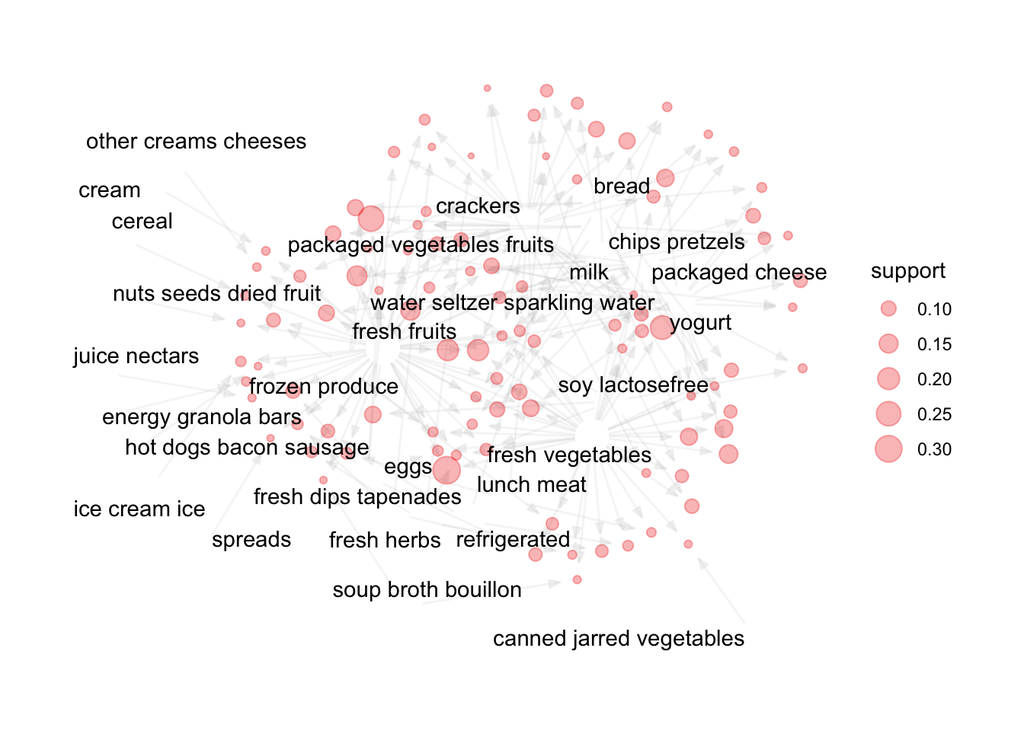

```r
plot(hunter_ECLAT, method = "graph")
```

```r
## Minimum support = 0.15
start_E3 <- Sys.time() # Untuk mengukur masa pelaksanaan algoritma ECLAT

hunter_ECLAT3<- eclat(data = hunter_trans, parameter = list(supp = 0.15, minlen = 2))
```

```
## Eclat
##
## parameter specification:
##  tidLists support minlen maxlen            target  ext
##     FALSE    0.15      2     10 frequent itemsets TRUE
##
## algorithmic control:
##  sparse sort verbose
##       7   -2    TRUE
##
## Absolute minimum support count: 29993
##
## create itemset ...
## set transactions ...[132 item(s), 199954 transaction(s)] done [0.11s].
## sorting and recoding items ... [10 item(s)] done [0.01s].
## creating bit matrix ... [10 row(s), 199954 column(s)] done [0.01s].
## writing  ... [7 set(s)] done [0.00s].
## Creating S4 object  ... done [0.00s].
```

```r
hunter_E3<- sort(hunter_ECLAT3, by="support", decreasing = T)
end_E3 <- Sys.time() #
time_E3<- as.numeric(end_E3 - start_E3) #

## Minimum support = 0.2
start_E4 <- Sys.time() # Untuk mengukur masa pelaksanaan algoritma ECLAT

hunter_ECLAT4<- eclat(data = hunter_trans, parameter = list(supp = 0.2, minlen = 2))
```

```
## Eclat
##
## parameter specification:
##  tidLists support minlen maxlen            target  ext
##     FALSE     0.2      2     10 frequent itemsets TRUE
##
## algorithmic control:
##  sparse sort verbose
##       7   -2    TRUE
##
## Absolute minimum support count: 39990
##
## create itemset ...
## set transactions ...[132 item(s), 199954 transaction(s)] done [0.11s].
## sorting and recoding items ... [6 item(s)] done [0.01s].
## creating bit matrix ... [6 row(s), 199954 column(s)] done [0.01s].
## writing  ... [3 set(s)] done [0.00s].
## Creating S4 object  ... done [0.00s].
```

```r
hunter_E4<- sort(hunter_ECLAT4, by="support", decreasing = T)
end_E4 <- Sys.time() #
time_E4<- as.numeric(end_E4 - start_E4) #

## Minimum support = 0.25
start_E5 <- Sys.time() # Untuk mengukur masa pelaksanaan algoritma ECLAT

hunter_ECLAT5<- eclat(data = hunter_trans, parameter = list(supp = 0.25, minlen = 2))
```

```
## Eclat
##
## parameter specification:
##  tidLists support minlen maxlen            target  ext
##     FALSE    0.25      2     10 frequent itemsets TRUE
##
## algorithmic control:
##  sparse sort verbose
##       7   -2    TRUE
##
## Absolute minimum support count: 49988
##
## create itemset ...
## set transactions ...[132 item(s), 199954 transaction(s)] done [0.11s].
## sorting and recoding items ... [4 item(s)] done [0.01s].
## creating bit matrix ... [4 row(s), 199954 column(s)] done [0.02s].
## writing  ... [2 set(s)] done [0.00s].
## Creating S4 object  ... done [0.00s].
```

```r
hunter_E5<- sort(hunter_ECLAT5, by="support", decreasing = T)
end_E5 <- Sys.time() #
time_E5<- as.numeric(end_E5 - start_E5) #

## Minimum support = 0.3
start_E6 <- Sys.time() # Untuk mengukur masa pelaksanaan algoritma ECLAT

hunter_ECLAT6<- eclat(data = hunter_trans, parameter = list(supp = 0.3, minlen = 2))
```

```
## Eclat
##
## parameter specification:
##  tidLists support minlen maxlen            target  ext
##     FALSE     0.3      2     10 frequent itemsets TRUE
##
## algorithmic control:
##  sparse sort verbose
##       7   -2    TRUE
##
## Absolute minimum support count: 59986
##
## create itemset ...
## set transactions ...[132 item(s), 199954 transaction(s)] done [0.11s].
## sorting and recoding items ... [3 item(s)] done [0.01s].
## creating bit matrix ... [3 row(s), 199954 column(s)] done [0.01s].
## writing  ... [1 set(s)] done [0.00s].
## Creating S4 object  ... done [0.00s].
```

```r
hunter_E6<- sort(hunter_ECLAT6, by="support", decreasing = T)
end_E6 <- Sys.time() #
time_E6<- as.numeric(end_E6 - start_E6) #
```

## Penilaian prestasi algoritma Analisis Bakul Pemasaran

> Prestasi setiap algoritma diukur berdasarkan satu kriteria penting, iaitu waktu yang diperlukan untuk menjalankan algoritma (masa pelaksanaan algoritma).

```r
# Masa pelaksanaan algoritma Apriori
time_A
```

```
## [1] 0.391526
```

```r
time_A2
```

```
## [1] 0.275718
```

```r
time_A3
```

```
## [1] 0.2432871
```

```r
time_A4
```

```
## [1] 0.2331572
```

```r
time_A5
```

```
## [1] 0.2163692
```

```r
time_A6
```

```
## [1] 0.2060962
```

```r
# Masa pelaksanaan algoritma ECLAT
time_E
```

```
## [1] 0.3682489
```

```r
time_E2
```

```
## [1] 0.160269
```

```r
time_E3
```

```
## [1] 0.1626451
```

```r
time_E4
```

```
## [1] 0.1655209
```

```r
time_E5
```

```
## [1] 0.1733041
```

```r
time_E6
```

```
## [1] 0.194278
```

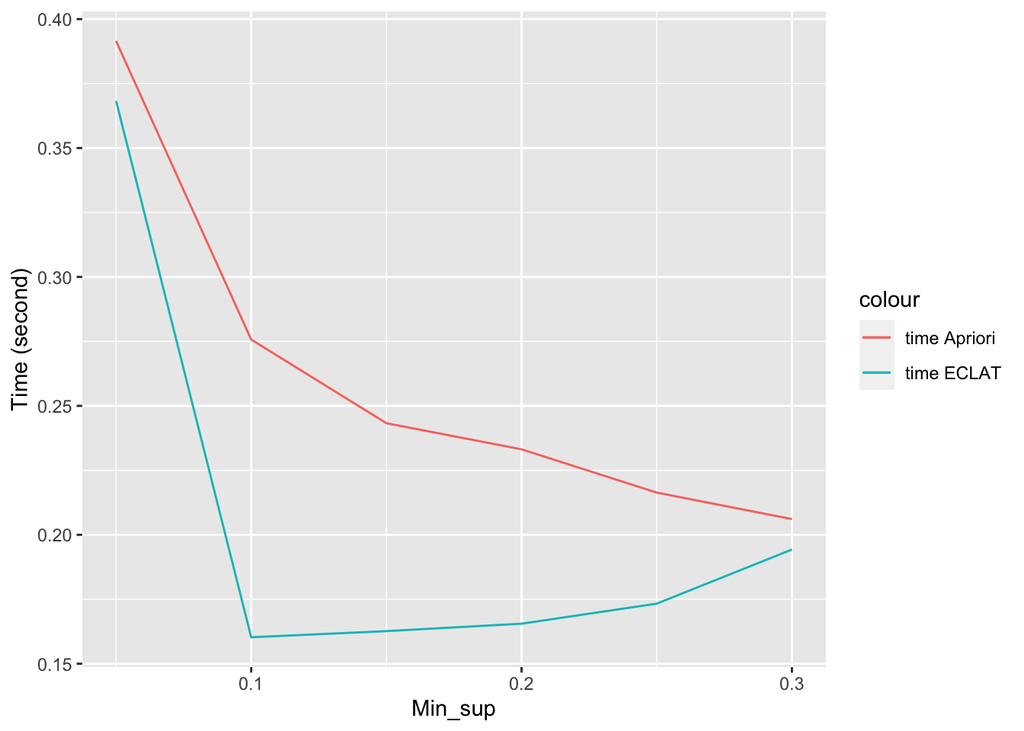

```r
Min_sup <- c(0.05,0.1,0.15,0.2,0.25,0.3)
time_Apriori <- c(time_A, time_A2, time_A3, time_A4, time_A5,time_A6)
time_ECLAT <- c(time_E, time_E2, time_E3, time_E4, time_E5,time_E6)
time_MBA<- data.frame(Min_sup,time_Apriori,time_ECLAT)

ggplot(time_MBA, aes(Min_sup)) +
  geom_line(aes(y=time_Apriori, colour="time Apriori")) +
  geom_line(aes(y=time_ECLAT, colour="time ECLAT")) +
  ylab("Time (second)")
```

```r
t.test(time_MBA$time_Apriori,time_MBA$time_ECLAT)
```

```
##
##  Welch Two Sample t-test
##
## data:  time_MBA$time_Apriori and time_MBA$time_ECLAT
## t = 1.3134, df = 9.7094, p-value = 0.2192
## alternative hypothesis: true difference in means is not equal to 0
## 95 percent confidence interval:
##  -0.04007925  0.15404175
## sample estimates:
## mean of x mean of y
## 0.2610256 0.2040443
```